# MLBD / Lab 2 / Features extraction

## Report submission

This laboratory will be graded, so you have to submit a report. You can work in groups of up to 3 persons and submit a report for each group with the following constraint :

- the report must be **AT MOST** 4 pages
- it should contain answers to the questions asked in this notebook
- it should contain an explanation of the feature you implemented with an overview of how it works (e.g. show some examples) and why you think it is useful
- include your results (either as classification report or confusion matrix) for both the kNN and the neural network classifiers
- include a graph showing the training error of your neural network over epochs (like the example ones at the end of this notebook)
- include the parameters you chosed for the neural network (number of neurons, learning rate, momentum, number of epochs) and why you picked them
- include an analysis of your results

Also include a copy of your scripts (.ipynb or .py) that you used WITHOUT the data. The grading will **ONLY be based on the report** and if we have to look at your scripts to understand what you did, it's a bad sign.

## Introduction

In this laboratory, we will work with images of plant leaves. The goal is to identify the plant species from the image.

To do so, we will use some concepts that have been presented in the theoretical part of the course :

- Feature extraction to turn an image into a vector of features
  - This will involve using PCA (Principal Component Analysis)
- Multi-Layer Perceptron (a type of artificial neural network) to perform the classification

### Dataset information

We will use the ImageClef 2012 Plant classification dataset. To simplify things, we have already extracted a small part of the dataset that we will be working on (in the "data/preprocessed" directory).

The notebook additionals/lab2_preprocess contains the preprocessing code (background substraction, image size normalization) that was used to create the subset of the data used in this laboratory.

Note that **it is not required** to download the full dataset. Neither do you need to run the lab2_preprocess notebook as this has already been done for you. But you can have a look if you are interested.

The full dataset can be downloaded from :

http://www.imageclef.org/2012/plant

The direct link is :

http://otmedia.lirmm.fr/LifeCLEF/ImageCLEF2011-2012-2013/ImageCLEF2012PlantIdentificationTaskFinalPackage.zip

It is interesting to download this dataset and have a look at the files in *data/SomeStatAndHtmlViewBySpecies/TrainAndTestViewsBySpecies*, which gives a nice overview of the type of plants in the dataset.

This dataset was originally used in a challenge. In the *OralPresentationsAndPosters* directory, there are some presentations from the teams that participated in the challenge with information about the type of preprocessing, features and classifiers used. This is very interesting if you are looking for inspiration about what you could implement.

Note about OpenCV

We will use the OpenCV image processing library to extract some features from the images. You can install it using anaconda with the following command :

```
$ conda install opencv
```

You should then be able to import the OpenCV python module, called **cv2**.

## Dataset overview

```python
import os
import cv2 # opencv
import pandas as pd
import numpy.ma as ma
import numpy.linalg as la
import skimage
import skimage.io
import pylab as pl
import matplotlib.cm as cm
%pylab inline --no-import-all
np.set_printoptions(precision=5, suppress=True)
```

```python
DIR = 'data/preprocessed/'
meta = pd.io.pickle.read_pickle(os.path.join(DIR, 'meta.pkl'))

def load_img(name):
    """Loads the given image by name and returns a masked array"""
    img = skimage.io.imread(os.path.join(DIR, 'imgs', name + ".png"))
    img = skimage.img_as_float(img)
    img = ma.masked_where(img == 0, img)
    # same mask for all 3 axes
    mask = np.all(img == 0, axis=2)
    img = ma.array(img)
    for i in xrange(img.shape[2]):
        img.mask[:,:,i] = mask

    return img
```

The meta dataframe contains information for each image :

- *basename* is the filename (without extension) of the image.
- *content* gives information about the image content. To simplify the problem, we selected only images of plant leaves on uniform backgrounds, but the original dataset has more variety.
- *classid* is the class. We selected 9 classes from the original dataset.
- *photo_type* is the type of photo. To simplify, we used only scan and pseudoscan (=uniform background) images

```python
meta.iloc[:5]
```

|  | basename | content | classid | photo_type |
| --- | --- | --- | --- | --- |
| 49 | 10047 | leaf | arbutus unedo | pseudoscan |
| 70 | 10073 | leaf | nerium oleander | pseudoscan |
| 85 | 10092 | leaf | nerium oleander | scan |
| 117 | 10129 | leaf | acer campestre | scan |
| 123 | 10135 | leaf | quercus pubescens | pseudoscan |

You can use the *load_img* function to load an image.

**masked arrays** Note that we are using [numpy *masked* arrays](http://docs.scipy.org/doc/numpy/reference/maskedarray.html), which are a special type of numpy array that have a mask. The mask is a boolean array that indicates if an entry is valid (mask[i,j] == False) or invalid (mask[i,j] == True). For our images, the background pixels are all masked. You can access the mask by using the .mask attribute of the array. Below, we use img.filled(1) to get a copy of the array with masked values replaced by 1.

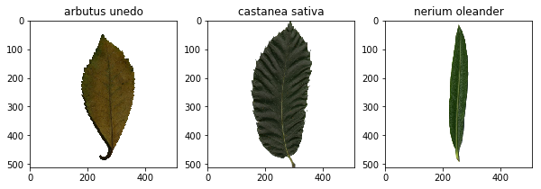

```python
# Show 3 example images
examples = [0, 50, 300]

pl.figure(figsize=(10, 3))
for i, idx in enumerate(examples):
    pl.subplot(1, 3, i + 1)
    img = load_img(meta.iloc[idx]['basename'])
    pl.title(meta.iloc[idx]['classid'])
    pl.imshow(img.filled(1))
```

```python
# The classes we will work with
print np.unique(meta['classid'])
```

```
['acer campestre' 'ailanthus altissima' 'alnus glutinosa' 'arbutus unedo'
 'castanea sativa' 'liquidambar styraciflua' 'nerium oleander'
 'quercus pubescens' 'vitex agnus-castus']
```

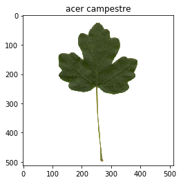

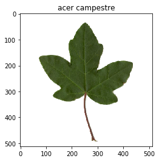

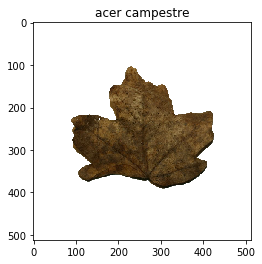

```python
# You can plot some examples images for a given species
import random
examples = np.flatnonzero(meta['classid'] == 'acer campestre')

for idx in random.sample(examples, 3):
    pl.figure()
    img = load_img(meta.iloc[idx]['basename'])
    pl.title(meta.iloc[idx]['classid'])
    pl.imshow(img.filled(1))
```

## Features extraction

So, we have images of leaves and we want to train a classifier to automatically determine the species of a leaf.

What should we use as input vectors for our classifier ?

The bruteforce approach could be to use a flattened version of all the image pixels (you concatenate all the rows in the image). Since we have images that have a size of 512x512, this would result in 262144 (512*512) dimensional input vectors.

For most classifiers, this is way too much dimensions. Also, this would mean that if you translate your image by one pixel, the input vector will change dramatically. Later in the course, we will see that deep learning classifiers are able to use data in such an unprocessed form, but for now, we have to extract features.

The better approach is to extract features to represent each image. If we ask you to manually classify those images, what will you look at ? Color ? The general shape of the leaf (i.e. elongated, round) ? The texture of the leaf ?

We will try to extract features that allow our classifier to use the same kind of hints that a human would use. We will start with two features : *eccentricity* and *curvature*. You will then have to propose and implement a new feature and see how the new information impacts classification performance.

First, we define some utility functions :

```python
def get_plant_points(img):
    """
    Given the image of a plant, returns a Nx2 array containing the (x, y) coordinate
    of all non-masked points
    """
    # this returns (y, x) tuple
    points = np.transpose(np.nonzero(~img.mask)[:2])
    # makes that an (x, y) tuple
    points = np.roll(points, 1, axis=1)
    return points

def extract_contour(img):
    """
    Wrapper around OpenCV's contour extraction methods. This returns only the longest
    contour
    """
    im2, contours, hierarchy = cv2.findContours(
        skimage.img_as_ubyte(~img.mask[:,:,0]),
        cv2.RETR_EXTERNAL,
        cv2.CHAIN_APPROX_NONE
    )

    # only take longest contour into account
    longest_contour = np.argmax([len(c) for c in contours])
    cnt = contours[longest_contour]
    cnt = np.squeeze(cnt)
    return cnt
```

### Eccentricity

Eccentricity gives us information about how the distribution of the leaf points deviates from a perfect circle.

The *get_plant_points* method above gives us the coordinate $(x, y)$ of all foreground (non-masked) points in the image. If we perform PCA on those points, we get two orthogonal (uncorrelated) principal axis (components) which are :

- The first axis is the axis with maximum variance
- The second axis is orthogonal to the first

In addition, each axis (which are the eigenvectors of the covariance matrix of our data) has an associated eigenvalue. The eigenvalue informs us about the relative importance of each axis.

We compute the eccentricity as the ratio of the eigenvalues of the two axis. If our points are distributed in a perfect circle, both axes will have equal importance and the ratio will be 1.

```python
from sklearn.decomposition import PCA

def eccentricity(img, plot=False):
    """Compute eccentricity : the ratio of the eigenvalues of principal components"""
    points = get_plant_points(img)
    pca = PCA(n_components=2).fit(points)
    centroid = pca.mean_
    eccentricity = pca.explained_variance_[0] / pca.explained_variance_[1]

    if plot:
        pl.title('eccentricity : %f' % eccentricity)
        pl.imshow(img)

        # direction of the two principal components
        d1 = pca.components_[0,:]
        d2 = pca.components_[1,:]

        scale = 100
        p1 = centroid + scale * d1 * pca.explained_variance_ratio_[0]
        pl.plot([centroid[0], p1[0]], [centroid[1], p1[1]], c='r')

        p2 = centroid + scale * d2 * pca.explained_variance_ratio_[1]
        pl.plot([centroid[0], p2[0]], [centroid[1], p2[1]], c='y')

        pl.xlim((0, img.shape[1]))
        pl.ylim((img.shape[0], 0))

    return eccentricity
```

First, let's play with circles and ellipses

```
4.0057977326922627
```

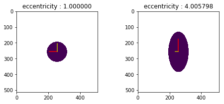

```python
import skimage.draw

def get_ellipse_image(yradius, xradius):
    img = ma.masked_all((512, 512), dtype=np.float)
    rr, cc = skimage.draw.ellipse(256, 256, yradius=yradius, xradius=xradius, shape=(512, 512))
    img[rr, cc] = 1
    return img

pl.figure(figsize=(8, 3))
pl.subplot(121)
# This is a circle
eccentricity(get_ellipse_image(64, 64), plot=True)

pl.subplot(122)
# An ellipse
eccentricity(get_ellipse_image(128, 64), plot=True)
```

Ok so now we can apply eccentricity on our images

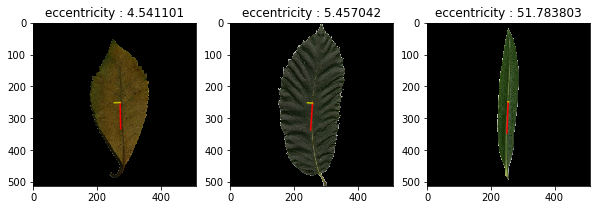

```python
examples = [0, 50, 300]
pl.figure(figsize=(10, 3))
for i, idx in enumerate(examples):
    pl.subplot(1, 3, i + 1)
    img = load_img(meta.iloc[idx]['basename'])
    eccentricity(img, plot=True)
```

### Curvature

We will compute the [curvature](http://en.wikipedia.org/wiki/Curvature#Curvature_of_plane_curves) of the contour of the leaf. This will help describe the "pointiness" of the contour.

The function does the following steps :

- Extract the leaf contour (using OpenCV's contour extraction functions).
- Compute the curvature for each point on the contour.
- Compute an histogram of all the curvatures of contour points.

The final feature vector will be the histogram. The number of bins in the histogram define the dimensionality of the feature vector.

There are three parameters that are important when computing our curvature feature :

- *step* : To compute curvature for a given point, we need a previous and next point and then use those 3 points to construct a circumcircle, the (inverse of the) radius of which is the curvature. The step determine how far away we pick our previous and next point.

[figure not shown]

- *nbins* and *vmax* : When computing our histogram of curvatures, we have to decide the number of bins in the histogram. We also have to decide the range of the bins, which will be in [0, vmax] .

```python
from matplotlib import gridspec

def circumcircle_radius(p1, p2, p3):
    """
    Given 3 points of a triangle, computes the radius of the circumcircle
    http://www.mathopenref.com/trianglecircumcircle.html

    This function can return np.inf if the triangle has an area of zero
    """
    a = la.norm(p2 - p1)
    b = la.norm(p3 - p2)
    c = la.norm(p1 - p3)
    #print a, b, c

    # Check for degenerate case (triangle has an area of zero)
    denom = np.fabs((a+b+c)*(b+c-a)*(c+a-b)*(a+b-c))
    if abs(denom) < 1e-5:
        return np.inf
    else:
        r = (a * b * c)/np.sqrt(denom)
        return r

def curvature_from_cnt(line, step=10):
    """
    Curvature computation for a line given as a Nx2 array
    We assumes the line is closed (ie the last and first point are contiguous)

    Each set of 3 consecutive (see step) points on the line forms a triangle
    and the radius of the circumcircle of this triangle is the radius of
    the curve for that set. The curvature is 1/r where r is this radius.

    Taking immediatly consecutive points doesn't work well, so `step` specify
    how points triplets are formed : (i-step, i, i+step)
    """
    # Append line end at beginning and beginning at end to simulate closed
    # line
    l = np.r_[line[-1].reshape(-1, 2),
              np.array(line),
              line[0].reshape(-1, 2)]
    curv = []
    linelen = line.shape[0]
    for i in xrange(linelen):
        # indices in l are shifted by -1
        #r = circumcircle_radius(l[i], l[i+1], l[i+2])
        r = circumcircle_radius(line[(i-step)%linelen],
                                line[i],
                                line[(i+step)%linelen])
        if np.isinf(r):
            # Flat => curvature = 0
            curv.append(0)
        else:
            curv.append(1.0 / r)
    return np.array(curv)

def curvature(img, step=10, plot=False, gs=None):
    cnt = extract_contour(img)

    cvt = curvature_from_cnt(cnt, step=step)

    if plot:
        if gs is None:
            gs = gridspec.GridSpec(1, 2)
        vimg = skimage.img_as_ubyte(img)
        cv2.drawContours(vimg, [cnt], 0, (0,255,0), 3)

        pl.subplot(gs[0])
        pl.title('contour')
        pl.imshow(vimg)
        pl.axis('off')

        pl.subplot(gs[1])
        pl.title('curvature')
        pl.imshow(img)
        pl.scatter(cnt[:,0], cnt[:,1], c=cvt, linewidths=0, s=5)
        pl.xlim((0, img.shape[1]))
        pl.ylim((img.shape[0], 0))
        pl.axis('off')

    return cvt
```

Q: Implement the curvature_hist function.

This function should take an image as input and return a vector of dimension $n$ representing the histogram of contour curvatures for the given image with $n$ bins. The signature should be :

```
def curvature_hist(img, n, vmax, step=10, plot=False):
    # implement here
```

```python
# MLBD - Labo
# Curvature_histo fonction
# input : img, n : number of bins, vmax = max value
# ouptut: a vector of dimension  n (bin)
def curvature_hist(img, n, vmax, step=10, plot=False):
    bin=n
    RMax=float(vmax)
    points = curvature(img, step=10, plot=False, gs=None)
    hist , bin_edges=np.histogram(points,bin,range=[0.0, RMax])
    resul=[]
    for j in range(0,bin):
        resul.append(hist[j])

    if plot:
        pl.figure(figsize=(10, 3))
        plt.hist(points,bin,range=[0.0, RMax])
        plt.title(curvature)
        plt.xlabel("curvature")
        plt.ylabel("Frequency")

        fig = plt.gcf()
    return resul
```

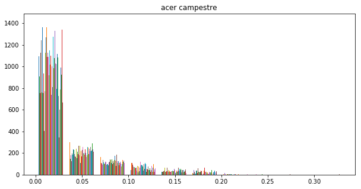

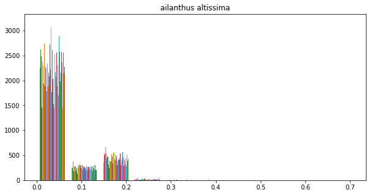

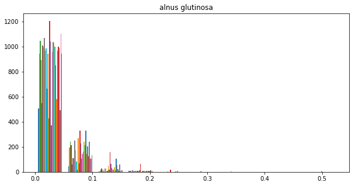

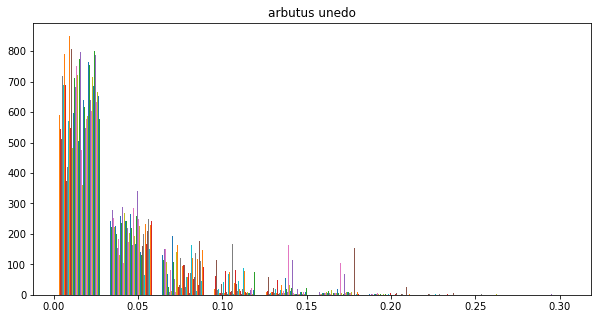

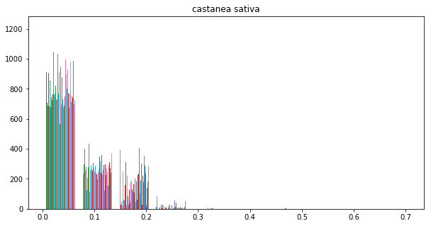

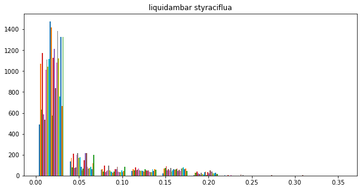

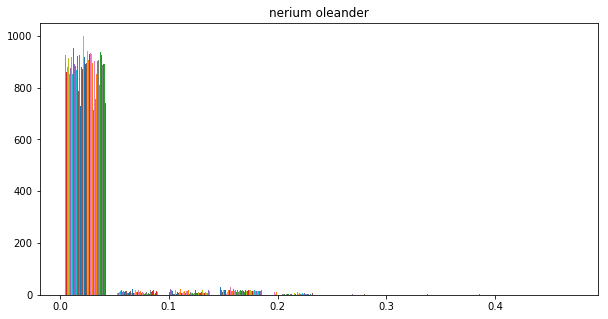

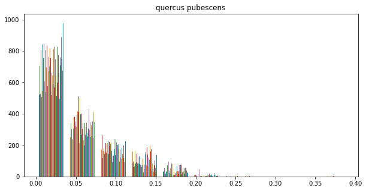

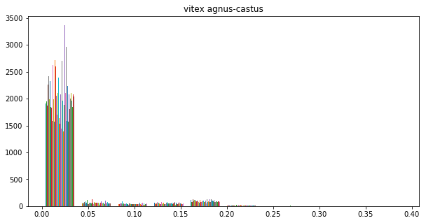

```python
# MLBD - Labo
# view distribution by class to determine the vmax
# we constate that the value varie between 0 to 0.3 => We will use 0.3 as Vmax
categorie=np.unique(meta['classid'])
points=[]
for j, jdx in enumerate(categorie):
    m = meta['classid'] == jdx
    examples=np.flatnonzero(m)
    points=[]
    for i, idx in enumerate(examples):
        img = load_img(meta.iloc[idx]['basename'])
        c = curvature(img, step=10, plot=False, gs=None)
        points.append(c)

    plt.figure(figsize=(10,5))
    plt.hist(points)
    plt.title(jdx)
    fig = plt.gcf()
```

```python
m1 = meta['classid'] == 'alnus glutinosa'
m2 = meta['classid'] == 'acer campestre'
print np.flatnonzero(m1)
print np.flatnonzero(m2)
```

```
[ 19  44  64 170 178 194 208 214 232 250 286 303 306 313 328 338 421 423
 433 444 478 484 507 512 516 537 540 574]
[  3   6  11  14  17  24  43  63  78  80  91  95 111 125 126 129 130 146
 182 200 213 246 248 264 273 280 281 282 289 290 292 295 307 318 319 325
 339 355 360 375 384 411 420 427 430 434 436 453 454 458 460 463 464 465
 508 510 513 527 530 531 541 552 555 557 558 562 566]
```

```
('vector of image ', 'alnus glutinosa', ' : ', [395, 130, 26, 1, 3, 6, 4, 0, 0, 0])
('vector of image ', 'acer campestre', ' : ', [1058, 247, 123, 56, 24, 25, 15, 0, 0, 0])
('vector of image ', 'acer campestre', ' : ', [889, 146, 83, 65, 37, 8, 10, 0, 0, 0])
```

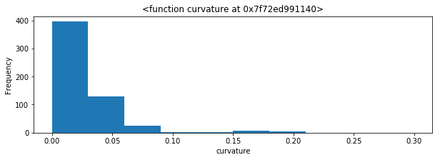

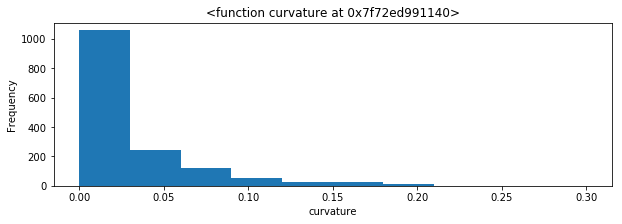

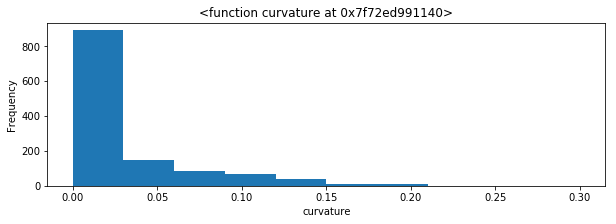

```python
# MLBD - Labo
# call curvature_hist to have vector of each image

N_BINS = 10 # à checker lors de l'entrainement du modèle , best bin => moins d'erreur possible
MAX_V = 0.3 # En regradant la distribution par classe, on constate que la valeur max dépasse rarement 0.3
examples = [19,3,11]
points=[]
for i, idx in enumerate(examples):

    img = load_img(meta.iloc[idx]['basename'])
    img_name= meta.iloc[idx]['classid']
    c = curvature_hist(img, N_BINS, MAX_V, step=10, plot=True)
    print ("vector of image ",img_name," : ", c)
```

### Implement your own features

http://www.math.uci.edu/icamp/summer/research_11/park/shape_descriptors_survey.pdf

Q: Implement a new feature

Implement a new feature extractor that you think could be useful for this classification task. Explain why your feature extractor is useful. You can look at the presentations accompanying the original dataset for inspiration. You can also start building on the convex hull example below.

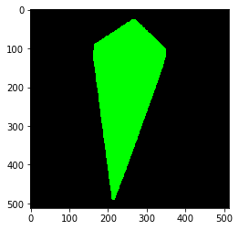

```python
# As an example, OpenCV allows you to compute the convex hull of a shape. An idea of feature might be
# to compute the ratio of area covered by valid pixels versus the convex hull area
cnt = extract_contour(img)
hull = cv2.convexHull(cnt)
vimg = skimage.img_as_ubyte(img)
cv2.drawContours(vimg, [hull], 0, (0,255,0), -1)
pl.imshow(vimg)
```

```python
# MLBD - Labo
def Convex(img):
    cnt = extract_contour(img)
    hull = cv2.convexHull(cnt)

    return cnt,hull

def Ratio_Convex(img):
    cnt, hull = Convex(img)

    p_cnt = cv2.contourArea(cnt) # get area of cnt
    p_hull = cv2.contourArea(hull) # get area of hull

    ratio = p_cnt/p_hull # ratio

    return ratio
```

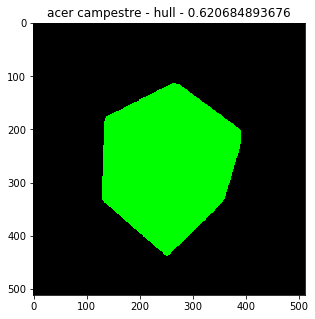

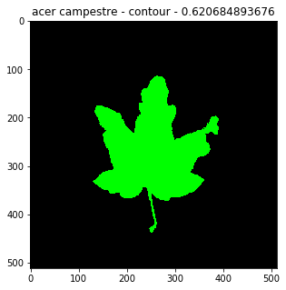

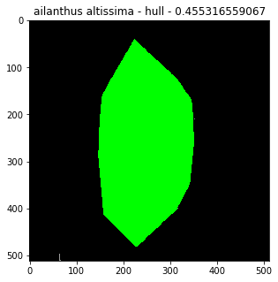

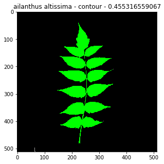

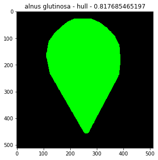

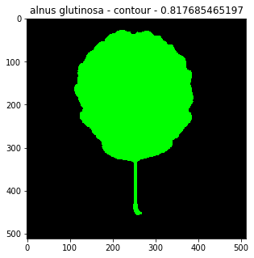

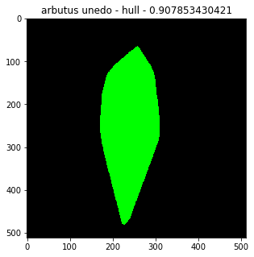

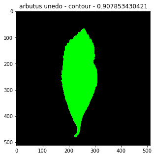

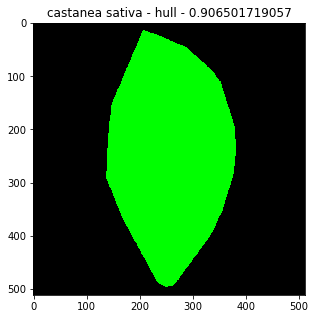

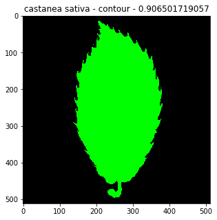

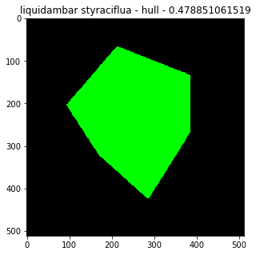

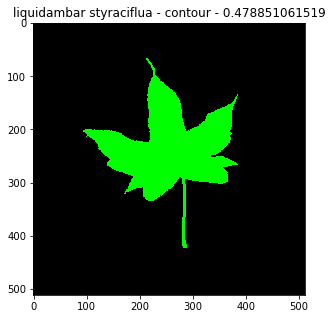

[6 more figures not shown]

```python
# MLBD - Labo
# view ratio (cnt/hull) of an image per class
categorie=np.unique(meta['classid'])
examples=[]
for i, idx in enumerate(categorie):
    m = meta['classid'] == idx

    id=np.flatnonzero(m)[1]

    img = load_img(meta.iloc[id]['basename'])
    cnt, hull = Convex(img)
    ratio= Ratio_Convex(img)

    # view hull
    plt.figure(figsize=(10,5))
    vimg = skimage.img_as_ubyte(img)
    cv2.drawContours(vimg, [hull], 0, (0,255,0), -1)
    plt.title(idx + " - hull - "+ str(ratio))
    pl.imshow(vimg)
    # view contour
    plt.figure(figsize=(10,5))
    vimg = skimage.img_as_ubyte(img)
    cv2.drawContours(vimg, [cnt], 0, (0,255,0), -1)
    plt.title(idx + " - contour - "+ str(ratio))
    pl.imshow(vimg)
```

```python
# MLBD - labo -> move on next section
# get output of Ratio_ConvexHull function
#nb_images = len(meta.iloc[:])
#ConvexHull_vector = np.zeros((nb_images,))
#for i in range(0, nb_images):
#    img = load_img(meta.iloc[i]['basename'])
#    ConvexHull_vector[i] = Ratio_Convex(img)
```

```python
#print ConvexHull_vector[0]
```

```python
# MLBD - labo -> move on next section
# get output of curvature function
#N_BINS = 3  # to find in training process
#MAX_V = 0.3
#nb_images = len(meta.iloc[:])
#curvature_vector = []
#for i in range(0, nb_images):
#    img = load_img(meta.iloc[i]['basename'])
#    c = curvature_hist(img, N_BINS, MAX_V, step=10, plot=False)
#    curvature_vector.append(c)
```

```python
#print curvature_vector[0]
```

```python
#print ConvexHull_vector.shape
#print eccentricity_vector.shape
#print len(curvature_vector)
#print curvature_vector
```

Q: Use the features to train and evaluate a k-NN classifier

This involves :

- Compute the feature vector of each image (by concatenating individual features of the image).
- Build a $n$ x $m$ data matrix $X$ with the feature vectors of all the images, where $n$ is the number of images and $m$ the number of features.
- Build an integer vector of length $n$, $y$, containing the target class for each image. *sklearn.preprocessing.LabelEncoder* is useful for converting text labels into integers.
- Normalizing your data. *sklearn.preprocessing.MinMaxScaler* might be useful (or other similar scaler classes)
- Split your dataset into training and test : X_train, X_test, y_train, y_test. *sklearn.model_selection* has useful utility functions for that.
- Build a classifier with *sklearn.neighbors.KNeighborsClassifier* on your training dataset and evaluate on your test dataset.
  - this needs to be done before executing the *y_pred = knn.predict(X_test)* cell